## Course: VISUAL ANALYTICS FOR POLICY AND MANAGEMENT

### Prof. José Manuel Magallanes, PhD

- Visiting Professor of Computational Policy at Evans School of Public Policy and Governance, and eScience Institute Senior Data Science Fellow, University of Washington.
- Professor of Government and Political Methodology, Pontificia Universidad Católica del Perú.

# Session 5: Tabular data: Bivariate Cat-Num

This time, I will use the [data about crime](https://data.seattle.gov/Public-Safety/Crime-Data/4fs7-3vj5) from the Seattle Open Data portal:

```r
# collecting the data
link="https://github.com/EvansDataScience/data/raw/master/crime.RData"
load(file = url(link))
```

The data available are:

```r
# variables in the data:
names(crime)
```

```
##  [1] "Report.Number"               "Occurred.Date"
##  [3] "year"                        "month"
##  [5] "weekday"                     "Occurred.Time"
##  [7] "Occurred.DayTime"            "Reported.Date"
##  [9] "Reported.Time"               "DaysToReport"
## [11] "crimecat"                    "Crime.Subcategory"
## [13] "Primary.Offense.Description" "Precinct"
## [15] "Sector"                      "Beat"
## [17] "Neighborhood"
```

We can also take a quick statistical look:

```r
# some stats:
summary(crime)
```

```
##  Report.Number      Occurred.Date             year          month
##  Length:499698      Min.   :1908-12-13   Min.   :1908   Min.   : 1.000
##  Class :character   1st Qu.:2010-10-26   1st Qu.:2010   1st Qu.: 4.000
##  Mode  :character   Median :2013-10-16   Median :2013   Median : 7.000
##                     Mean   :2013-08-08   Mean   :2013   Mean   : 6.501
##                     3rd Qu.:2016-05-11   3rd Qu.:2016   3rd Qu.: 9.000
##                     Max.   :2018-11-06   Max.   :2018   Max.   :12.000
##                     NA's   :2            NA's   :2      NA's   :2
##       weekday       Occurred.Time   Occurred.DayTime  Reported.Date
##  Friday   : 77662   Min.   :   0   day      :108648   Min.   :1975-12-16
##  Saturday : 73340   1st Qu.: 900   afternoon:155725   1st Qu.:2010-11-02
##  Thursday : 71441   Median :1500   evening  :119061   Median :2013-10-21
##  Wednesday: 70898   Mean   :1360   night    :116262   Mean   :2013-08-16
##  Tuesday  : 70593   3rd Qu.:1922   NA's     :     2   3rd Qu.:2016-05-17
##  (Other)  :135762   Max.   :2359                      Max.   :2018-11-06
##  NA's     :     2   NA's   :2
##  Reported.Time   DaysToReport                    crimecat
##  Min.   :   0   Min.   :    0.00   THEFT             :170946
##  1st Qu.: 950   1st Qu.:    0.00   CAR PROWL         :142447
##  Median :1407   Median :    0.00   BURGLARY          : 76630
##  Mean   :1354   Mean   :    7.65   AGGRAVATED ASSAULT: 21315
##  3rd Qu.:1818   3rd Qu.:    1.00   NARCOTIC          : 16864
##  Max.   :2359   Max.   :36525.00   (Other)           : 71234
##  NA's   :2      NA's   :2          NA's              :   262
##             Crime.Subcategory      Primary.Offense.Description
##  CAR PROWL           :142447   THEFT-CARPROWL    :126166
##  THEFT-ALL OTHER     : 51577   THEFT-SHOPLIFT    : 46381
##  THEFT-SHOPLIFT      : 46381   THEFT-OTH         : 44850
##  BURGLARY-RESIDENTIAL: 45203   VEH-THEFT-AUTO    : 36455
##  MOTOR VEHICLE THEFT : 41870   BURGLARY-FORCE-RES: 27087
##  (Other)             :171958   THEFT-BUILDING    : 20395
##  NA's                :   262   (Other)           :198364
##       Precinct          Sector            Beat
##  EAST     : 74010   M      : 41091   K3     : 16130
##  NORTH    :160307   U      : 38729   U1     : 14362
##  SOUTH    : 71206   K      : 36278   L2     : 13911
##  SOUTHWEST: 47019   B      : 35882   M1     : 13878
##  WEST     :143988   D      : 34010   Q3     : 13769
##  NA's     :  3168   (Other):310546   (Other):424533
##                     NA's   :  3162   NA's   :  3115
##               Neighborhood
##  DOWNTOWN COMMERCIAL: 46754
##  NORTHGATE          : 29477
##  CAPITOL HILL       : 29361
##  QUEEN ANNE         : 26139
##  SLU/CASCADE        : 22328
##  (Other)            :342460
##  NA's               :  3179
```

In this material, we are interested in how a categorical variable can help us better understand a numeric variable. Given the data we will be using, the curiosity and experience of the analyst is critical in mining the data to reveal some insight, as numerical data have longer value ranges than categorical data.

In the previous data set we had a variable that informs the amount of days it takes someone to report a crime:

```r
# stats of days to report
# notice the spread of values.
summary(crime$DaysToReport)
```

```
##     Min.  1st Qu.   Median     Mean  3rd Qu.     Max.     NA's
##     0.00     0.00     0.00     7.65     1.00 36525.00        2
```

Let me see the crimes that took the longest:

```r
# 'order' decreasing

library(magrittr) # for %>%
crime[order(-crime$DaysToReport),c('year','DaysToReport')]%>%head(20)
```

```
##      year DaysToReport
## 6783 1908        36525
## 7995 1964        16801
## 7998 1975        15198
## 8001 1976        15154
## 8002 1977        15116
## 7997 1974        14345
## 7996 1973        14268
## 8007 1980        11992
## 8003 1978        11559
## 8005 1979        11396
## 8012 1986        11292
## 8010 1985        11125
## 8006 1980        11105
## 8011 1985        10622
## 8013 1987         9503
## 8017 1990         9131
## 8023 1993         8924
## 8020 1993         8880
## 8015 1989         8795
## 8016 1990         8032
```

Do you think this is right? The longest one was from 1908. Let’s assume it is OK (but I am pretty sure it is not).

There are several good categorical variables that can be used to study the behavior of the time it takes to report a crime. Let’s use *precint* (only the ones non missing):

```r
# non missing 'precint'
crime=crime[complete.cases(crime$Precinct),]

# summary: mean by groups
aggregate(data=crime, DaysToReport~Precinct,mean)
```

```
##    Precinct DaysToReport
## 1      EAST     7.216687
## 2     NORTH     7.104350
## 3     SOUTH     7.219687
## 4 SOUTHWEST    11.063208
## 5      WEST     4.897332
```

Above, you see the mean time (in days) it takes per precint for people to notify a crime. You can suddenly create a plot in your mind just by reading those values, but the plot you imagine may be far from this one:

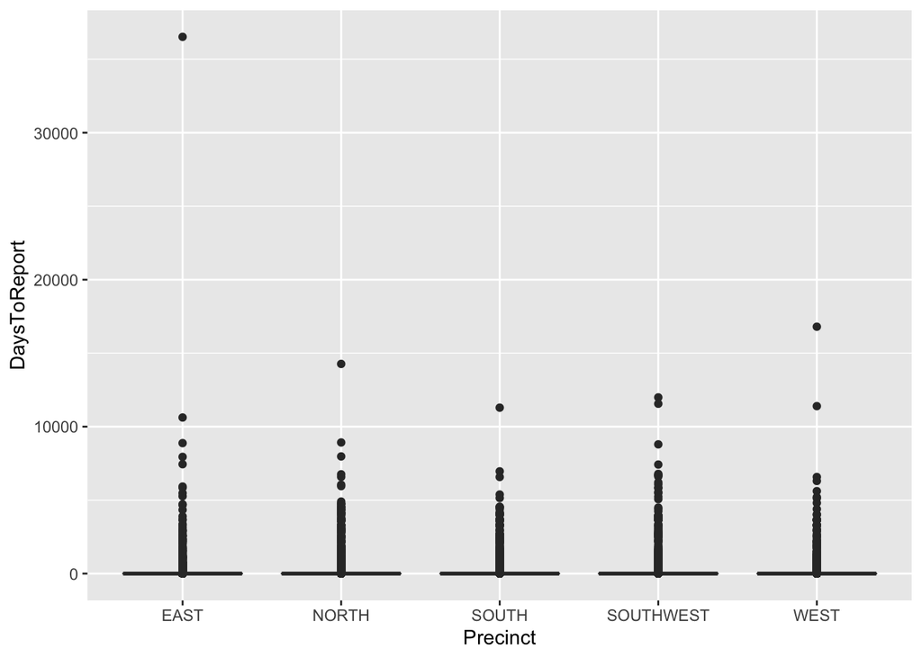

```r
# boxplot of days to report per precint

library(ggplot2)
base=ggplot(data=crime,
            aes(x=Precinct,y=DaysToReport))

base + geom_boxplot()
```

The plot above would not give so much insight, there is so much noise. The fact is that a better summary would tell us more to consider:

```r
# aggregate using "summary" function
# Distribution of days to report?

aggregate(data=crime,DaysToReport~Precinct,summary)
```

```
##    Precinct DaysToReport.Min. DaysToReport.1st Qu. DaysToReport.Median
## 1      EAST          0.000000             0.000000            0.000000
## 2     NORTH          0.000000             0.000000            0.000000
## 3     SOUTH          0.000000             0.000000            0.000000
## 4 SOUTHWEST          0.000000             0.000000            0.000000
## 5      WEST          0.000000             0.000000            0.000000
##   DaysToReport.Mean DaysToReport.3rd Qu. DaysToReport.Max.
## 1          7.216687             1.000000      36525.000000
## 2          7.104350             1.000000      14268.000000
## 3          7.219687             1.000000      11292.000000
## 4         11.063208             1.000000      11992.000000
## 5          4.897332             1.000000      16801.000000
```

From the information above, you know that for each precint, the 75% of crimes are reported in a day or less. If we consider that situation as the expected behavior, let me omit those cases. Let me explore by week or more using **ggarrange**:

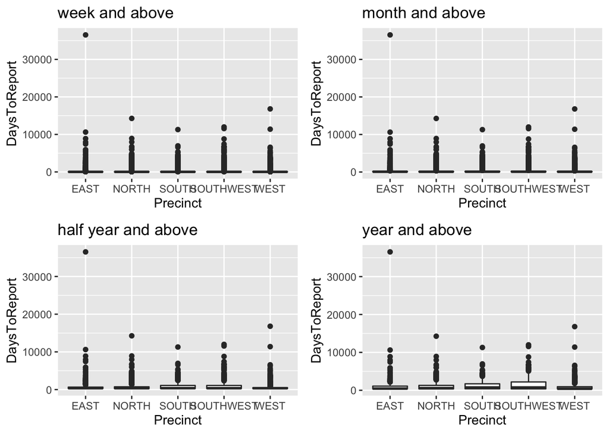

```r
# several boxplots, from week and above

library(ggpubr)

base7=ggplot(data=crime[crime$DaysToReport>=7,],
            aes(x=Precinct,y=DaysToReport))
box7=base7 + geom_boxplot() + labs(title = "week and above")

base30=ggplot(data=crime[crime$DaysToReport>=30,],
            aes(x=Precinct,y=DaysToReport))
box30=base30 + geom_boxplot() + labs(title = "month and above")

base180=ggplot(data=crime[crime$DaysToReport>=180,],
            aes(x=Precinct,y=DaysToReport))
box180=base180 + geom_boxplot() + labs(title = "half year and above")


base365=ggplot(data=crime[crime$DaysToReport>=360,],
            aes(x=Precinct,y=DaysToReport))
box365=base365 + geom_boxplot() + labs(title = "year and above")



#all in one:
ggarrange(box7,box30,box180,box365)
```

Up to this point, you need to be planing a good *story*. The situation is different for each case, but let’s build our story from the crimes that take a year or longer to report.

The year the crime occurred would be another variable to consider, to see if we can filter more cases:

```r
# check crimes per year to filter again
table(crime$year)
```

```
##
##  1908  1964  1973  1975  1978  1979  1980  1981  1985  1986  1988  1989
##     1     1     1     1     1     2     1     2     1     1     1     1
##  1991  1993  1994  1995  1996  1997  1998  1999  2000  2001  2002  2003
##     2     5     2     5     3     3    18     5    33    49    15    25
##  2004  2005  2006  2007  2008  2009  2010  2011  2012  2013  2014  2015
##    36    40    92   601 42451 44772 43060 41020 40764 45259 49092 47486
##  2016  2017  2018
## 48941 49927 42810
```

If we were to plot by year, several years before 2000 are too few. Let’s get rid of those old cases and keep the crimes that took a year or more to report:

```r
# let's keep durantion longer than a year,
# and after 2000

# new filtered data frame
crimeY2000=crime[crime$year>=2000 & crime$DaysToReport>=365,]

#counting
table(crimeY2000$Precinct)
```

```
##
##      EAST     NORTH     SOUTH SOUTHWEST      WEST
##       257       543       237       214       358
```

Now, we see a better boxplot:

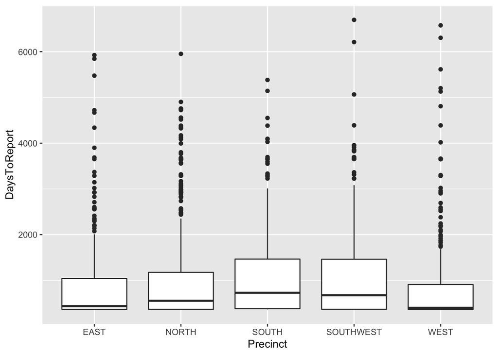

```r
# box plot for new filtered data frame:

base=ggplot(data=crimeY2000,
            aes(x=Precinct,y=DaysToReport))
base + geom_boxplot()
```

For sure, it would be better if the numerical units were in years:

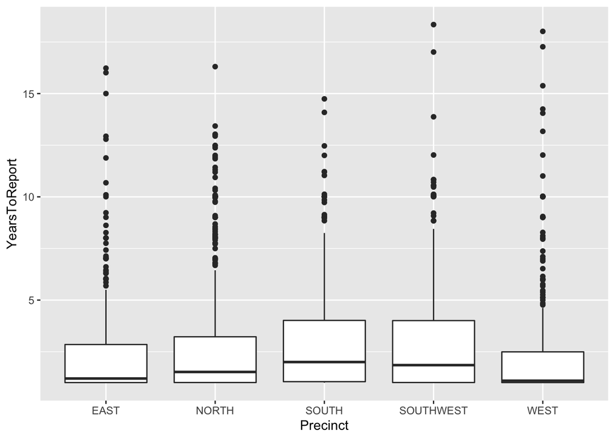

```r
# create new variable in YEARS:
crimeY2000$YearsToReport=crimeY2000$DaysToReport/365

# new box plot, only vertical units change
base=ggplot(data=crimeY2000,
            aes(x=Precinct,y=YearsToReport))
base + geom_boxplot()
```

If your story is about the similarity of distributions among precincts, you can start improving the last plots. But in case you need to show some variety you can try another relevant categorical variable.

Let’s try *crimecat* and *year*:

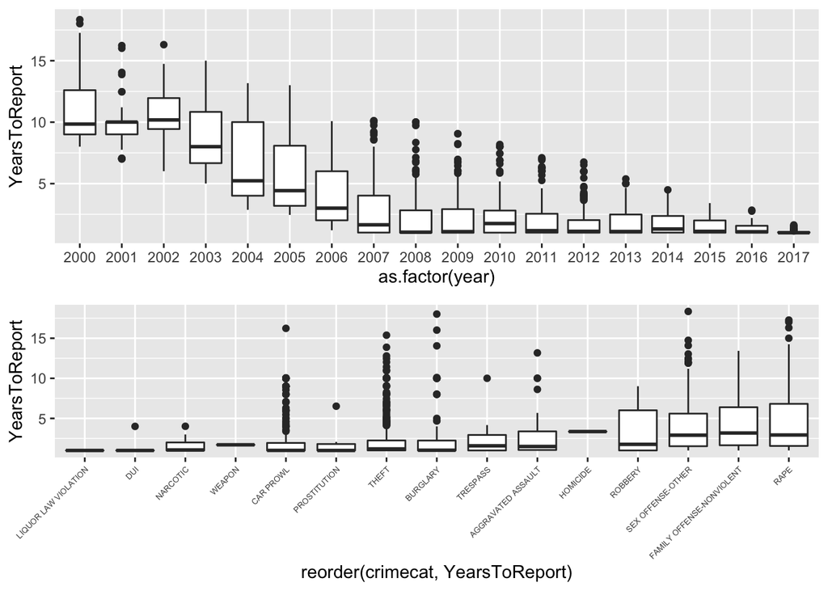

```r
#boxplot by Year
base=ggplot(data = crimeY2000,
            aes(x=as.factor(year),
                y=YearsToReport))
boxByYear=base + geom_boxplot()

#boxplot by Crime
base=ggplot(data =crimeY2000,
            aes(x=reorder(crimecat,YearsToReport), # using reorder!
                y=YearsToReport))
boxByCrime=base + geom_boxplot()
boxByCrime= boxByCrime + theme(axis.text.x = element_text(angle = 45,
                                                          hjust = 1,
                                                          size = 5))
# combining plots
ggarrange(boxByYear,boxByCrime,ncol = 1)
```

Let’s focus in years to report, the top plot. It may be the case that your audience does not know how to read a boxplot. It is a great plot, but encoding so much statistical information. Then we can go simple, and use lines connecting the easy-to-understand points in every boxplot:

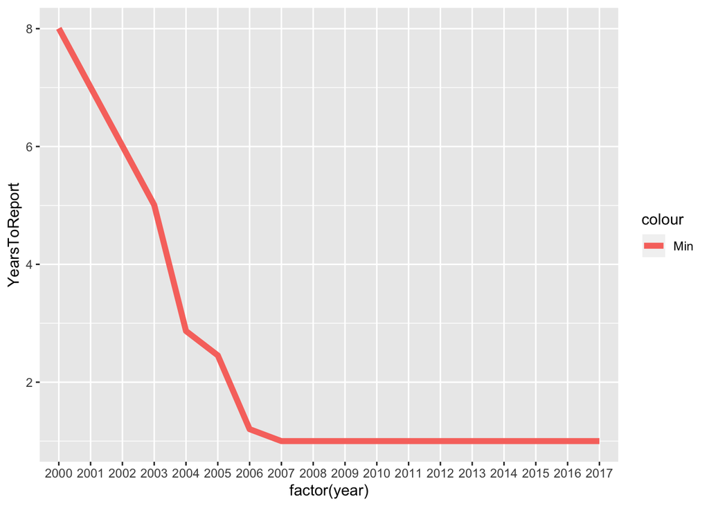

```r
# plotting the MIN values:
base  = ggplot(crimeY2000,aes(x=factor(year), y=YearsToReport))
mins = base + stat_summary(fun.y=min, # function for 'y' is min()
                           geom="line",
                           size=2,
                           aes(group=1,col='Min'))
mins # just the min values
```

Let me add the max values:

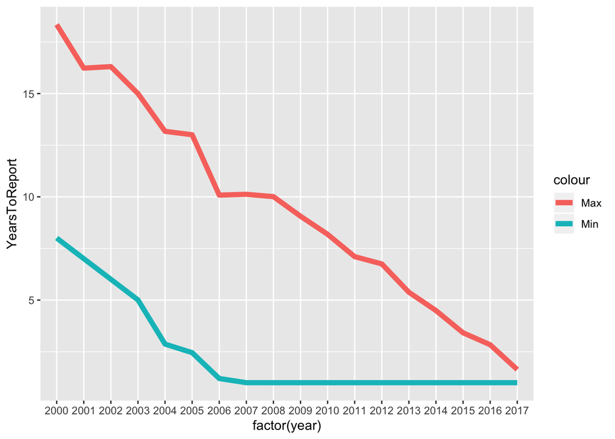

```r
# plotting the MAX values on top:
minsMaxs= mins + stat_summary(fun.y=max,
                              geom="line",
                              size=2,
                              aes(group=1,col='Max'))

minsMaxs
```

Adding the median:

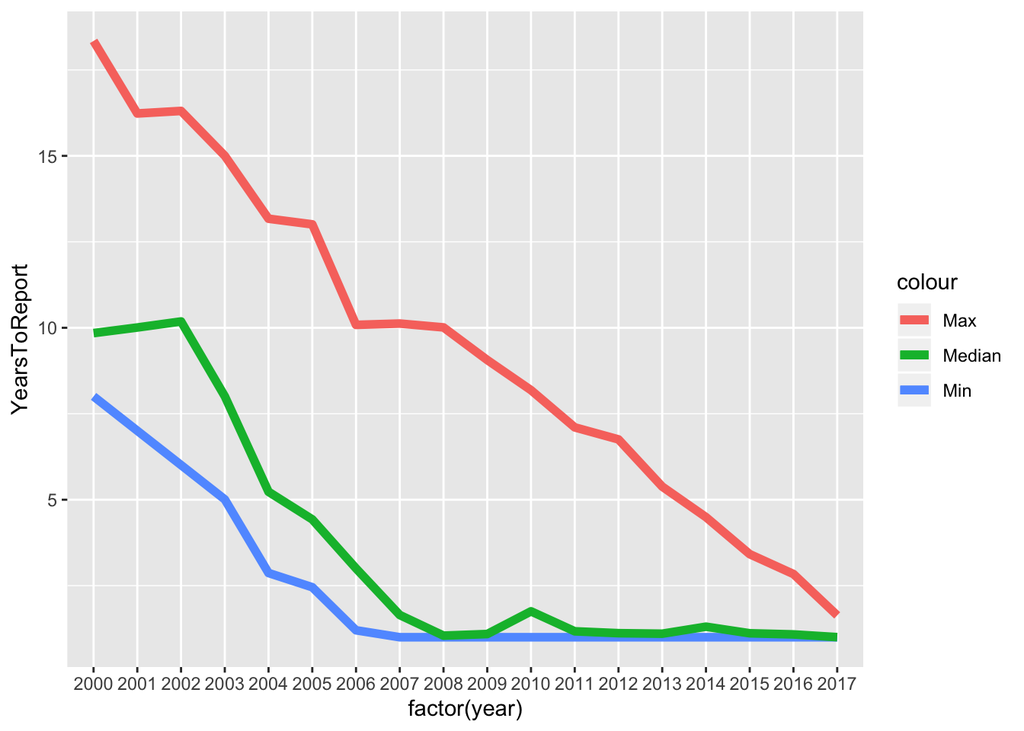

```r
# another layer with MEDIANS
minsMaxsMd= minsMaxs + stat_summary(fun.y=median,
                                    geom="line",
                                    size=2,
                                    aes(group=1,col='Median'))
minsMaxsMd
```

Let’s take control of the colors by customizing the legend:

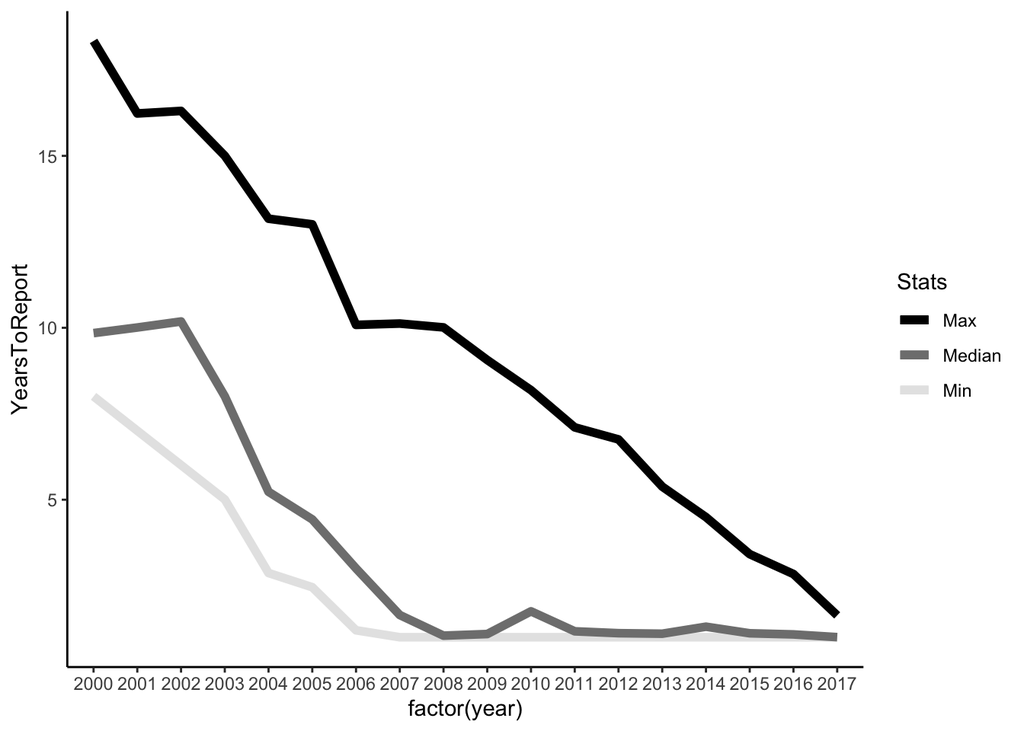

```r
# Change color of lines:
all1=minsMaxsMd + scale_colour_manual(name="Stats",
                                      values=c("black", "grey50","grey90") #alphabetic
                                      )
all1 + theme_classic()
```

Now, let’s complete the story by telling how the data filtered behaves, that is, the crimes that took less than a year to report since 2000 (we will not include data from before):

```r
# data we did not use:

crimeLessYear2000=crime[(crime$DaysToReport<365) & (crime$year>=2000),]
```

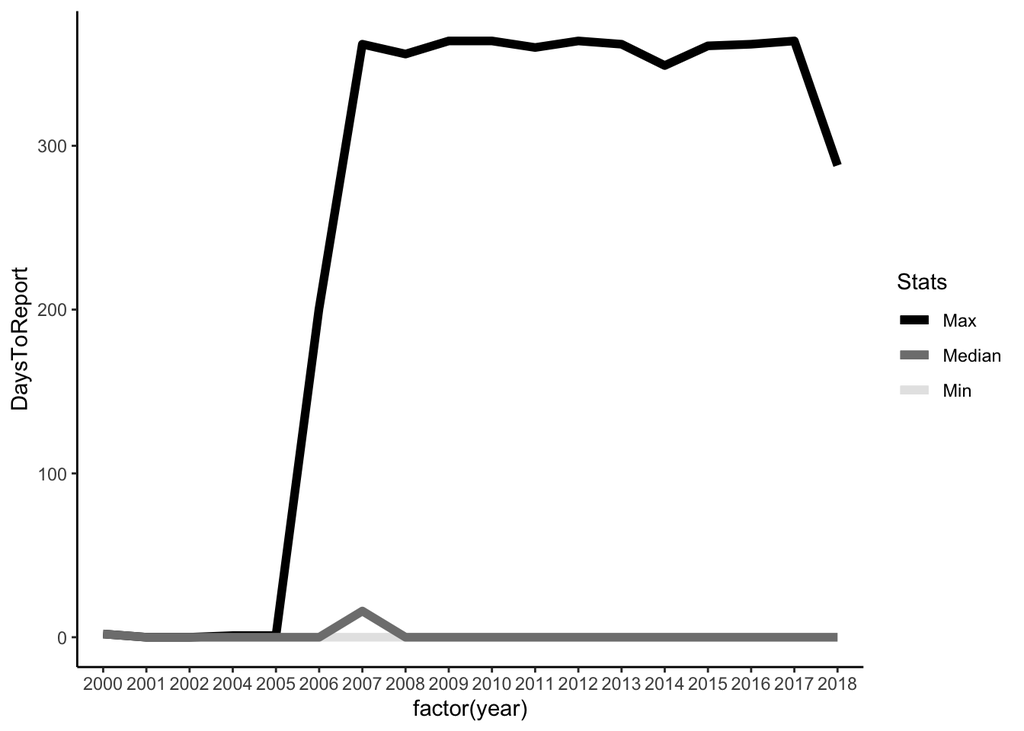

```r
#plotting it as before:
base = ggplot(crimeLessYear2000,aes(x=factor(year), y=DaysToReport))
mins = base + stat_summary(fun.y=min,size=2,
                           geom="line",
                           aes(group=1,col='Min'))
minsMaxs= mins + stat_summary(fun.y=max,
                              geom="line",size=2,
                              aes(group=1,col='Max'))
minsMaxsMd= minsMaxs + stat_summary(fun.y=median,
                                    geom="line",size=2,
                                    aes(group=1,col='Median'))
all2=minsMaxsMd + scale_colour_manual(name="Stats",
                                      values=c("black", "grey50","grey90")
                                      )
all2 + theme_classic()
```

## Some statistical considerations

It is very common to hear in scientific texts about the mean difference test known as the **one-way anova**, which beyond describing, as we have done, seeks to show if the mean of the numerical variable varies or not accross the values of the categorical groups.

So, to know the average time it takes to report a crime:

```r
#checking the mean per factor value.
#are crime in precints different on average?

aggregate(data=crimeY2000,YearsToReport~Precinct, mean)
```

```
##    Precinct YearsToReport
## 1      EAST      2.544971
## 2     NORTH      2.907702
## 3     SOUTH      3.230599
## 4 SOUTHWEST      3.295967
## 5      WEST      2.424137
```

```r
#are crime in precints different on average?
library(Rmisc)
group.CI(YearsToReport ~ Precinct,
         data=crimeY2000,
         ci = 0.95)
```

```
##    Precinct YearsToReport.upper YearsToReport.mean YearsToReport.lower
## 1      EAST            2.883462           2.544971            2.206480
## 2     NORTH            3.154218           2.907702            2.661186
## 3     SOUTH            3.608395           3.230599            2.852804
## 4 SOUTHWEST            3.737035           3.295967            2.854899
## 5      WEST            2.712811           2.424137            2.135464
```

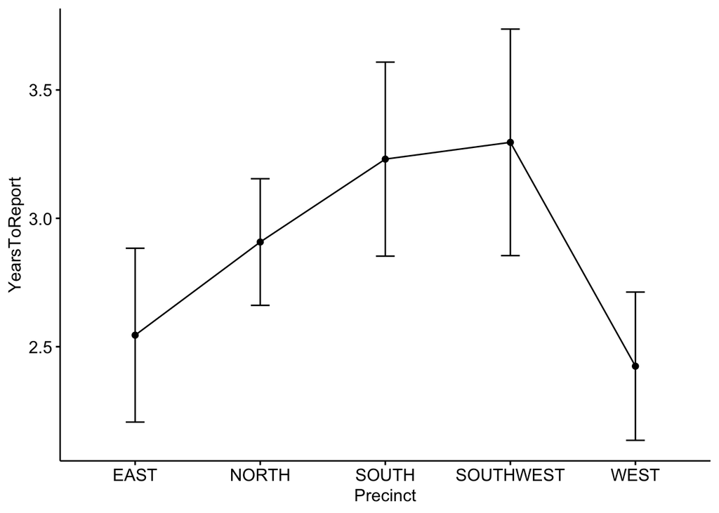

```r
#are crime in precints different on average?

# introducing ggpubr
library(ggpubr)
ggline(data=crimeY2000,x = "Precinct", y = "YearsToReport",
       add = 'mean_ci')
```

```r
# Compute the analysis of variance
res.aov <- aov(YearsToReport ~ Precinct, data = crimeY2000)

# Summary of the analysis
summary(res.aov)
```

```
##               Df Sum Sq Mean Sq F value   Pr(>F)
## Precinct       4    167   41.85   4.911 0.000617 ***
## Residuals   1604  13672    8.52
## ---
## Signif. codes:  0 '***' 0.001 '**' 0.01 '*' 0.05 '.' 0.1 ' ' 1
```

```r
# where are the differences detected in aov?
TukeyHSD(res.aov)
```

```
##   Tukey multiple comparisons of means
##     95% family-wise confidence level
##
## Fit: aov(formula = YearsToReport ~ Precinct, data = crimeY2000)
##
## $Precinct
##                        diff         lwr         upr     p adj
## NORTH-EAST       0.36273106 -0.24092583  0.96638795 0.4713106
## SOUTH-EAST       0.68562844 -0.03238799  1.40364487 0.0694107
## SOUTHWEST-EAST   0.75099628  0.01317929  1.48881326 0.0436917
## WEST-EAST       -0.12083381 -0.77267399  0.53100637 0.9867702
## SOUTH-NORTH      0.32289738 -0.29780707  0.94360182 0.6143830
## SOUTHWEST-NORTH  0.38826522 -0.25524105  1.03177148 0.4670240
## WEST-NORTH      -0.48356487 -1.02635584  0.05922609 0.1071367
## SOUTHWEST-SOUTH  0.06536784 -0.68646078  0.81719646 0.9992978
## WEST-SOUTH      -0.80646225 -1.47412083 -0.13880366 0.0087890
## WEST-SOUTHWEST  -0.87183009 -1.56073813 -0.18292204 0.0050944
```

```r
# where are the differences detected in aov?
# result into a data frame
ResPar=as.data.frame(TukeyHSD(res.aov)$Precinct)
ResPar[ResPar$`p adj`<0.05,]
```

```
##                      diff         lwr        upr       p adj
## SOUTHWEST-EAST  0.7509963  0.01317929  1.4888133 0.043691732
## WEST-SOUTH     -0.8064622 -1.47412083 -0.1388037 0.008788960
## WEST-SOUTHWEST -0.8718301 -1.56073813 -0.1829220 0.005094405
```

```r
# non parametric
kruskal.test(YearsToReport ~ Precinct, data = crimeY2000)
```

```
##
##  Kruskal-Wallis rank sum test
##
## data:  YearsToReport by Precinct
## Kruskal-Wallis chi-squared = 37.72, df = 4, p-value = 1.28e-07
```

```r
# where are the differences detected in Kruskal?
library(FSA)
dunnTest(YearsToReport ~ Precinct, data = crimeY2000)
```

```
## Dunn (1964) Kruskal-Wallis multiple comparison
```

```
##   p-values adjusted with the Holm method.
```

```
##           Comparison         Z      P.unadj        P.adj
## 1       EAST - NORTH -1.987948 4.681748e-02 1.872699e-01
## 2       EAST - SOUTH -3.878650 1.050379e-04 8.403029e-04
## 3      NORTH - SOUTH -2.553383 1.066822e-02 5.334112e-02
## 4   EAST - SOUTHWEST -2.653576 7.964395e-03 4.778637e-02
## 5  NORTH - SOUTHWEST -1.177634 2.389426e-01 4.778852e-01
## 6  SOUTH - SOUTHWEST  1.100093 2.712917e-01 2.712917e-01
## 7        EAST - WEST  1.258085 2.083611e-01 6.250833e-01
## 8       NORTH - WEST  3.721706 1.978812e-04 1.385168e-03
## 9       SOUTH - WEST  5.399473 6.683699e-08 6.683699e-07
## 10  SOUTHWEST - WEST  4.032357 5.522019e-05 4.969817e-04
```

```r
# where are the differences detected in Kruskal?
# result into a data frame
ResNonPar=dunnTest(YearsToReport ~ Precinct, data = crimeY2000)$res
ResNonPar[ResNonPar$P.adj<0.05,]
```

```
##          Comparison         Z      P.unadj        P.adj
## 2      EAST - SOUTH -3.878650 1.050379e-04 8.403029e-04
## 4  EAST - SOUTHWEST -2.653576 7.964395e-03 4.778637e-02
## 8      NORTH - WEST  3.721706 1.978812e-04 1.385168e-03
## 9      SOUTH - WEST  5.399473 6.683699e-08 6.683699e-07
## 10 SOUTHWEST - WEST  4.032357 5.522019e-05 4.969817e-04
```